# **About Me**

👋 Hi, I’m @DAWells 🦠 I’m interested in using multiomics and AI to treat disease 👨‍💻 I'm using long/short read NGS and knowledge graphs

Here I post useful snippets of code, demonstrations, and explorations of statistical techniques. If you would like to contact me please get in touch through [linkedIn](https://www.linkedin.com/in/david-wells-811444185/).

# **Posts**

[figure not shown]

**By any means**

The impact of different averages on rankings.

[figure not shown]

**Exploring cancer types with neo4j**

How to identify and visualise clusters in knowledge graphs.

[figure not shown]

**Codon pair optimisation**

Optimising genes with a genetic algorithm.

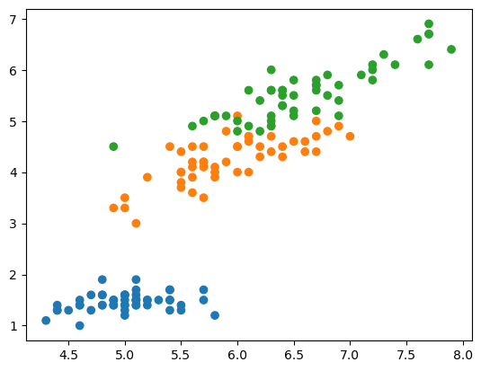

**Matplotlib cmap**

Simple demos of matplotlib's cmaps.

[figure not shown]

**Flu subtypes**

How is the flu sequence data distributed across subtypes, hosts and countries on the NCBI data base?

[figure not shown]

**Confusion matrix**

When reporting binary classification models, just looking at accuracy doesn't give the full picture. You need sensitivity & specificity, or precision & recall.

[figure not shown]

**ggtree samples**

Code snippets for various ggtree examples.

[figure not shown]

**Ordinal GLM**

When a response variable is ordered categories you can predict all categories using a single proportional odds model, instead of separate logistic regression models.

[figure not shown]

**Phylogenetic mixed modelling**

Simulate data for a phylogenetic mixed model using a phylogenetic tree to impose the phylogenetic covariance structure.

[figure not shown]

**Gaussian mixture**

Unsuperivsed classification based on bivariate data using a gaussian mixture model.

[figure not shown]

**Power & resolution**

When binning a continuous variable, e.g. into high and low, positive and negative, you lose information and statistical power.

[figure not shown]

**Additive mixed modelling**

Fitting an additive mixed model to account for both long an short term effects of time while fitting an autocorrelation structure to the residuals.

[figure not shown]

**Gaussian process**

Fitting a gaussian process to time series data. Using this approach domain knowledge can be used to choose an appropriate covariance function.

[figure not shown]

**Graphic Cite**

Web scraping, analysing, and interactive visualisations of data on scientific publishing.

[figure not shown]

**The Denatured**

A pop science outreach website produced by a small team of writers and vloggers which I organise.

[figure not shown]

**Jupyter Slides**

Easily turn your code, workflow, and results into a presentation. This is great for sharing results with or without your code.